# Chapter 3 - R0

Pablo Perez

30/10/2020

### Estimating R0 from a simple epidemic

For free-living organisms, the rate of exponential growth `r` given generation time `G` can be calculated as follows
$$r = log(R_0) / G$$
$$R_0 = exp(rG)$$

Since an exponentially growing population grows as a rate
$$N(t) = N(0)exp(rt)$$
the time for it to double will be
$$log(2)/r$$

For pathogens, `N` would represent disease prevalence and `G` the serial interval `V`, the time between successive cases in a chain of transmission. Since infectious disease data often is in the form of *incidence* (`i`), to calculate `R_0` we can first regress *log (cumulative incidence)* on time to estimate the rate of exponential increase `r`.
$$r = log(cumulative_i)\\R_0 = Vr + 1$$

#### Example: 2003 Niamey measles outbreak

We can first visusally inspect the data (`niamey` available in the package `epidemr`) to identify the initial period of exponential growth. Note the time series is provided in *weeks*, so we will need to use this as our basic time unit for subsequent calculations.

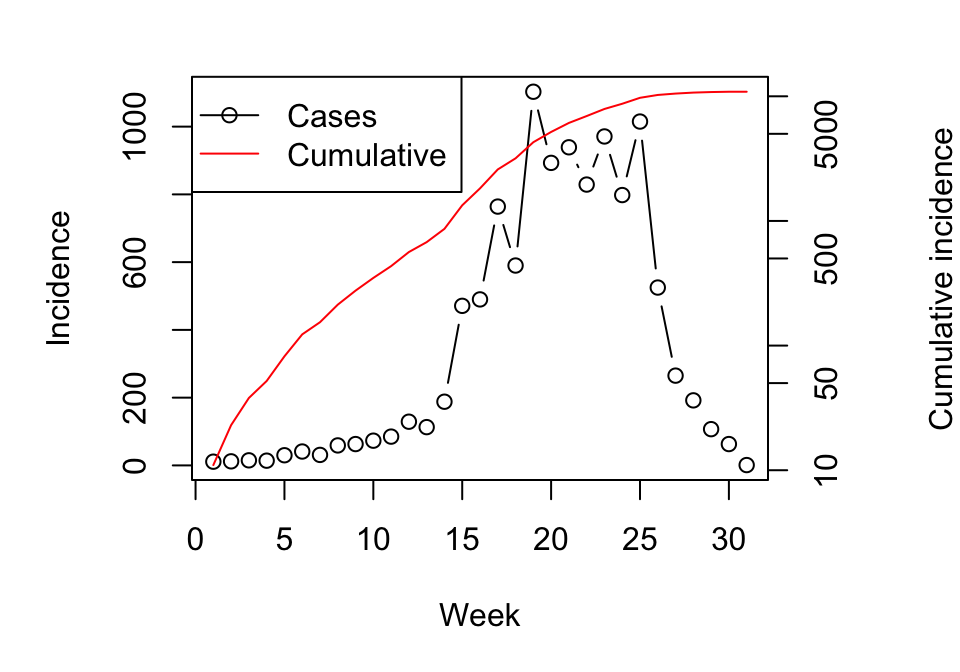

The serial interval for measles is of 10-12 days. Since data is weekly in this example, we can assume `V` of 1.5 or 1.8 and use the equations for a quick calculation for `R_0`, which places its value at between 1.7 and 1.8.
$$r = log(cumulative_i)\\R_0 = Vr + 1$$

```r
# Regressing cumulative incidence in time
fit=lm(log(cum_cases)~absweek, subset=absweek<7, data=niamey)

r=fit$coef["absweek"]
V=c(1.5, 1.8)
V*r+1
```

```
## [1] 1.694233 1.833080
```

##### Effective reproductive number

We can thus refine our estimate of `R` by acounting for the ratio of infectious period to serial interval (`f`). For measles, the infectious period is 5 days, or in our example `5/7` to put it in the same time scale. We can then use the following equation to solve for `R`
$$R = Vr + 1 + f(1-f)(Vr)^2$$

```r
f = (5/7)/V
V * r + 1 + f * (1 - f) * (V * r)^2
```

```
## [1] 1.814450 1.999198
```

This estimation of `R_E` places its value at between 1.8 and 2.0. Whilst its simplicity makes it very useful at the start of an outbreak, it’s based on initial growth only. For a full or evolving outbreak, though, such simple calculations are not very robust, as they rely on a fraction of the data.

### Maximum likelihood: the chain-binomial model

In contrast to the continuous-time, deterministic, basic-chain SIR model from chapter 2, the **chain-binomial model** assumes that an epidemic arises from a succession of discrete generations of infectious individuals in a *coin-flip* fashion given a **force of infection** (*β*)
$$\beta\ I/N$$

The negative of the above expression will thus be the probability that a *susceptible* individual escapes infection at time `t`. The number of events in `∆t` will follow a Poisson distribution (`x∆t`). Assuming that a) contacts happen at random and b) the serial interval is the basic unit of time `t`, the *stochastic chain-binomial model* can be represented as follows
$$I_{t+1} \sim Binomial(S_t, 1 - exp(-\beta\ I_t / N)\\S_{t+1} = S_t - I_{t+1} = S_0 - \sum_{i=1}^t I_i$$

If we ignore observational error, there are two unknown parameters in these expressions: the initial number of susceptibles (`S_0`) and the transmission rate. The reproductive ratio is a composite of these two
$$R = S_0(1−exp(−\beta /N))$$

For a large population, the reproductive ratio is approximately *β S0/N* because *1−exp(−x) ~ x* for *x << 1*. Thus *β* is approximately the reproductive ratio at the beginning of the epidemic, since infectious individuals are expected to transmit for exactly a time unit before recovering.

##### The removal method for parameter estimation in a chain-binomial model

Assuming *conditional independence* (i.e. each epidemic generation depends only on the state of the system in the previous time step), the **removal method** can estimate *β* and *S_0* from a sequence of binomial likelihoods. In contrast to the examples above with the Niamey measles outbreak, the removal method uses all available data and not just a few time points at the start of an outbreak.

We will implement the removal method by doing a ‘*non-standard*’ maximum-likelihood analysis:

1. We write a function (*model*) for the likelihood (`L`)
2. Our *model* needs to be parameterised by candidate values for *S_0* and *β*
3. Our data will be an actual case series of infected individuals *I*
4. Assuming a fully susceptible population at the start of the outbreak, *S_0* needs to be at least the number of actual cases in an epidemic
5. Our *model* can then be used to obtain the *negative log-likelihood* of observing the data given the model. In this example, the base R function `dbinom` is uses for this purpose

In this example, we will again use data from the Niamey measles outbreak for `district_1`. The outbreak lasted 31 weeks and there were a total of 5,920 cases in district 1. So we will use candidate values of 6,500 for *S_0* and a sequence of potential candidate values for *β* going from 0 to 10 by 0.1 increases. The weekly time series of cases will be our data for *I* at each time-step. Given the *serial interval* of measles is roughly two weeks, we will aggregate cases into two-weekly time steps.

```r
# Function to return negative log-likelihood of I given model parameters
llik.cb = function(S0, beta, I) {
  n = length(I)
  S = floor(S0 - cumsum(I[-n]))
  p = 1 - exp(-beta * (I[-n])/S0)
  L = -sum(dbinom(I[-1], S, p, log = TRUE))
  return(L)
}

# Candidate values for S_0 and beta
S0cand=6500
betacand=seq(0,10, by=.1)

# Aggregate cases in district 1 into two-weekly time steps
twoweek = rep(1:15, each = 2)
y = sapply(split(niamey$cases_1[1:30], twoweek), sum)

# Implement model and record outputs of negative log-likelihood
# We derive the beta candidate value that yields the lowest negative log-likelihood
ll=rep(NA, length(betacand))
for(i in 1:length(betacand)){
ll[i]=llik.cb(S0=S0cand, beta=betacand[i], I=y)
}
betacand[which.min(ll)]
```

```
## [1] 2.3
```

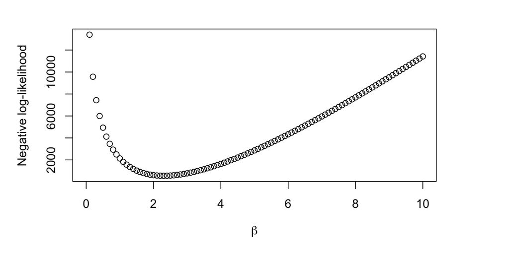

```r
par(mar = c(5,5,2,5))
p.beta <- plot(ll~betacand, ylab="Negative log-likelihood", xlab=expression(beta))
```

We thus estimate that, assuming *S_0 = 6,500*, the most plaussible value for *β* is of 2.3. Similarly, we can cross-check this proposed valua against a plaussible range for `S_0`.

```r
betacand=2.3
S0cand=seq(5920,8000, length=101)
ll=rep(NA, length=101)
for(i in 1:101){
  ll[i]=llik.cb(S0=S0cand[i], beta=betacand, I=y)
}
S0cand[which.min(ll)]
```

```
## [1] 7084.8
```

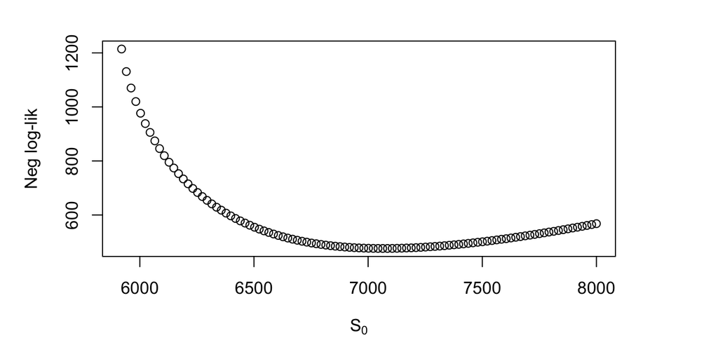

```r
par(mar = c(5,5,2,5))
plot(ll~S0cand, ylab="Neg log-lik", xlab=expression(S[0]))
```

##### Maximum likelihood for parameter estimation in a chain-binomial model

The value obtained for *S_0* (7,084.8) then tells us our guess is good, but imperfect. Using the `mle2` function from the `bbmle` package, both parameters can be varied at the same time for an estimate obtained by **maximum likelihood**. Whilst this method still yields imperfect results, it highlights our *uncertainty* given parameter interdependencies. Moreover, our uncertainty in parameter values can be quantified as a **variance-covariance** matrix.

```r
fit=mle2(llik.cb, start=list(S0=7085, beta=2.3),
         method="Nelder-Mead",data = list(I = y))
summary(fit)
```

```
## Maximum likelihood estimation
##
## Call:
## mle2(minuslogl = llik.cb, start = list(S0 = 7085, beta = 2.3),
##     method = "Nelder-Mead", data = list(I = y))
##
## Coefficients:
##        Estimate Std. Error z value     Pr(z)
## S0   7.8158e+03 1.3022e+02  60.019 < 2.2e-16 ***
## beta 1.8931e+00 3.6968e-02  51.209 < 2.2e-16 ***
## ---
## Signif. codes:  0 '***' 0.001 '**' 0.01 '*' 0.05 '.' 0.1 ' ' 1
##
## -2 log L: 841.831
```

```r
cov2cor(vcov(fit))
```

```
##              S0       beta
## S0    1.0000000 -0.7444261
## beta -0.7444261  1.0000000
```

Note the strong negative correlation between parameters here. For example, similar epidemic trajectories can arise from having a large number of initial susceptibles and a low transmission rate, or a more moderate number of susceptibles and a higher transmission rate.

#### Stochastic simulation

Building on the statistical part of the chain-binomial model, we can write a stochastic function for simulating dynamics given estimated parameters. Here, 100 simulations are superimposed on the observed epidemic and we can observe our model gives a reasonable approximation of the underlying dynamics, as the observed epidemic is wrapped around the model iterations.

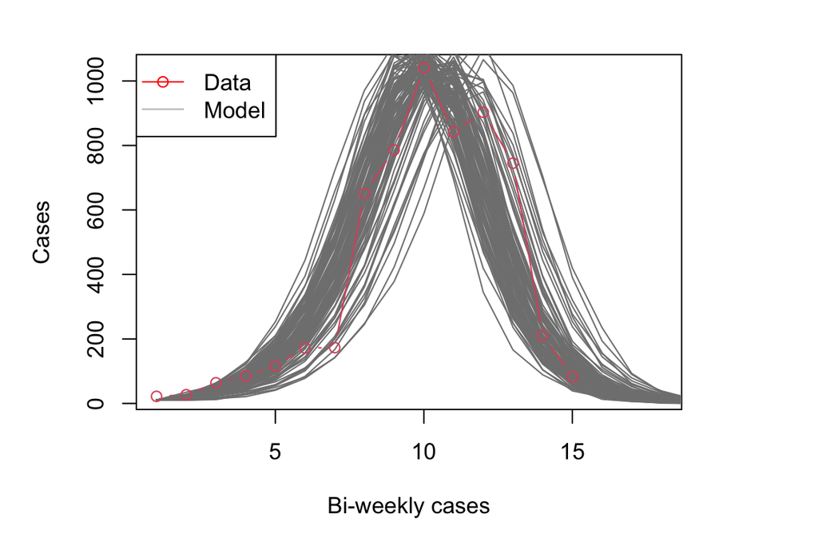

```r
par(mar = c(5,5,2,5))

sim.cb=function(S0, beta, I0){
  I=I0
  S=S0
  i=1
  while(!any(I==0)){
    i=i+1
    I[i]=rbinom(1, size=S[i-1], prob=1-
                  exp(-beta*I[i-1]/S0))
    S[i]=S[i-1]-I[i]
  }
  out=data.frame(S=S, I=I)
  return(out)
}

plot(y, type="n", xlim=c(1,18),
     ylab="Cases", xlab="Bi-weekly cases")
legend("topleft", legend=c("Data", "Model"),lty=c(1,1),
       pch=c(1,NA), col=c("red", "grey"))

for(i in 1:100){
  sim=sim.cb(S0=floor(coef(fit)["S0"]),
             beta=coef(fit)["beta"], I0=11)
  lines(sim$I, col=grey(.5))
}
points(y, type="b", col=2)
```